# Лабораторная работа № 12. Программирование в командном процессоре ОС UNIX. Командные файлы

НПИбд-03-25

Author

Чжу Ино

Published

2026-10-15

# 1 Цель работы

Изучить основы программирования в оболочке ОС UNIX/Linux. Научиться писать небольшие командные файлы.

# 2 Задачи

1. Написать скрипт, делающий резервную копию самого себя.
2. Написать командный файл, обрабатывающий аргументы командной строки.
3. Написать командный файл — аналог команды `ls`.
4. Написать командный файл для подсчёта файлов с заданным расширением.

# 3 Теоретические сведения

## 3.1 Командные процессоры

- `sh` — Bourne shell
- `csh` — C shell
- `ksh` — Korn shell
- `bash` — Bourne Again Shell

## 3.2 Переменные

```bash
mark=/usr/andy/bin
mv afile ${mark}
```

## 3.3 Арифметические вычисления

- `let` — арифметические выражения
- Операторы: `+`, `-`, `*`, `/`, `%`, `==`, `!=`, `<`, `>`, `<=`, `>=`
- `(( ))` — запись условий

## 3.4 Чтение ввода

```bash
read mon day trash
```

## 3.5 Метасимволы

- `*` — любая строка
- `?` — один символ
- `[c1-c2]` — диапазон

Экранирование: `\`, `'`, `"`.

## 3.6 Командные файлы

```bash
bash командный_файл [аргументы]
```

## 3.7 Условный оператор if

```bash
if список-команд
then список-команд
[elif список-команд
then список-команд]
[else список-команд]
fi
```

## 3.8 Циклы while и until

```bash
while список-команд
do список-команд
done
```

```bash
until список-команд
do список-команд
done
```

## 3.9 Прерывание циклов

- `break` — завершить цикл
- `continue` — завершить итерацию

# 4 Выполнение лабораторной работы

## 4.1 Скрипт 1: резервная копия

```bash
#!/bin/bash
tar -czf ~/backup_$(date +%Y%m%d).tar.gz "$0"
```

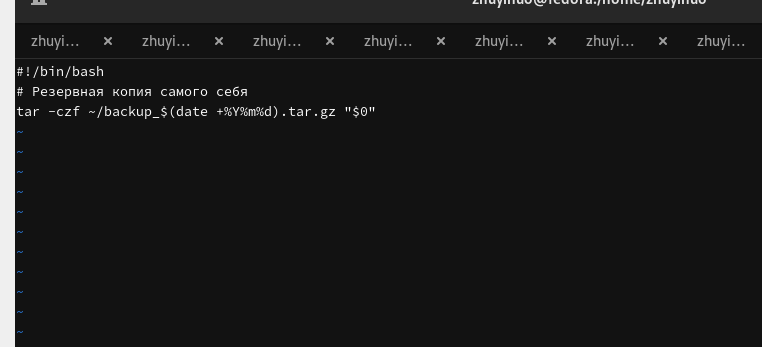

Figure 1: Скрипт backup

```bash
chmod +x backup.sh
./backup.sh
```

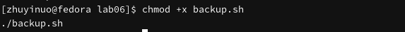

Figure 2: Запуск backup

```bash
ls -lh ~/backup_*.tar.gz
```

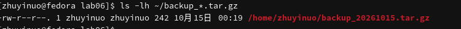

Figure 3: Проверка backup

## 4.2 Скрипт 2: аргументы

```bash
#!/bin/bash
for arg in "$@"; do
    if [ "$arg" -gt 10 ]; then
        echo "$arg"
    fi
done
```

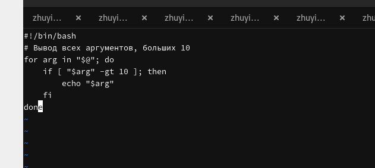

Figure 4: Скрипт args

```bash
chmod +x args.sh
./args.sh 5 12 8 20 3 15
```

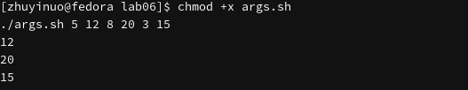

Figure 5: Запуск args

```bash
./args.sh
```

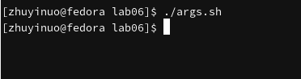

Figure 6: Без аргументов

## 4.3 Скрипт 3: аналог ls

```bash
#!/bin/bash
DIR="${1:-.}"
for file in "$DIR"/*; do
    if [ -d "$file" ]; then
        echo "d $file"
    elif [ -f "$file" ]; then
        echo "f $file"
    fi
done
```

[figure not shown]

Figure 7: Скрипт myls

```bash
chmod +x myls.sh
./myls.sh
```

[figure not shown]

Figure 8: Запуск myls

```bash
./myls.sh /etc
```

[figure not shown]

Figure 9: myls /etc

```bash
ls
```

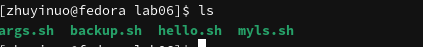

Figure 10: Сравнение